# Optimal shuttle location

Webster

23 November 2021

# 1 Exercise overview

It is a common practice for tech companies to use shuttle buses to ferry their employees from home to the office. The goal of this exercise is to figure out the optimal stops for a bus shuttle. The company is based in Mountain View and the shuttle provides transportation form employees based in San Francisco.

With the explosion of location and user data, data science can be used to optimize many of the services cities offer to their citizens. Transportation optimization is an example of that, but there are so many other possible applications. All this often goes under the name of “smart city” and it is one of the most interesting future applications of data science.

Company XYZ has decided to offer a shuttle bus to help its employees commute from San Francisco to Mountain View. The city of San Francisco has given the company a list of potential bus stop locations to choose from and asked to not have more than 10 stops within the city.

You have been given the home address of all employees interested in taking the shuttle and asked to come up with the ten most efficient stops. While you have been given a certain freedom in defining what is “efficient”, the general consensus within the company is that the most efficient way to select the bus stops is to minimize the overall walking distance between employee homes and the 10 bus stops.

Estimating all possible 10 stop combinations would require a lot of time (how many combinations would that be?). Therefore, your boss is fine with simplifying the problem and returning 10 stops that have a high probability of being the best stops.

You should write an algorithm that returns the best 10 stops in your opinion. Also, please explain the rationale behind the algorithm.

# 2 Load and explore data

## 2.1 First, load the data

```r
#Set seed for reproducibility
set.seed(1003)
#Set directory
i_am("01. Optimal shuttle locations.Rmd")

#Load data
employees <- read_csv(here("raw","Employee_Addresses.csv"))
head(employees)
```

```
## # A tibble: 6 × 2
##   address                                        employee_id
##   <chr>                                                <dbl>
## 1 98 Edinburgh St, San Francisco, CA 94112, USA          206
## 2 237 Accacia St, Daly City, CA 94014, USA              2081
## 3 1835 Folsom St, San Francisco, CA 94103, USA           178
## 4 170 Cambridge St, San Francisco, CA 94134, USA          50
## 5 16 Roanoke St, San Francisco, CA 94131, USA           1863
## 6 222 Whittier St, Daly City, CA 94014, USA              485
```

```r
stops <- read_csv(here("raw","Bus_Stops.csv"))
head(stops)
```

```
## # A tibble: 6 × 2
##   Street_One Street_Two
##   <chr>      <chr>
## 1 MISSION ST ITALY AVE
## 2 MISSION ST NEW MONTGOMERY ST
## 3 MISSION ST 01ST ST
## 4 MISSION ST 20TH ST
## 5 MISSION ST FREMONT ST
## 6 MISSION ST 13TH ST
```

# 3 10 best stops

As a first step, let’s geolocate all those addresses, which is really just a fancy way to say let’s get lat and long from the addresses. In general, whenever possible, it is always a good idea to go from addresses to lat/long.

Lat and long are continuous variables and most ML models deal very well with them, extracting tons of information. On the other hand, geographical variables stored as categorical variables (like country, state, city, address, etc) are particularly complicated for most models, especially because we typically end up having tons of different levels, each level having few events. And this is a nightmare for most ML models.

```r
#Geocode function via Bing Api
BingGeoCode <- function(string){
    u = URLencode(paste0("http://dev.virtualearth.net/REST/v1/Locations?q=", string, "&maxResults=1&key=Auxf825mnBqDYiijsjj_3LjianQlT2lPCxWsMf4IeTwXq9HXAV3n60BBUZmGXhO6"))
    d = getURL(u)
    j = fromJSON(d,simplify = FALSE)
    latitude = j$resourceSets[[1]]$resources[[1]]$point$coordinates[[1]]
    longitude = j$resourceSets[[1]]$resources[[1]]$point$coordinates[[2]]
    c(longitude, latitude)
}

#Note that Bing tries very hard to guess a correct address even if the format is not perfect. For instance, this address below does return a specific location by guessing. Other APIs would return NAs. Both ways (NA or guessing) are fine here and lead to comparable final results. Another approach would be cleaning the data before calling the API. For instance, removing all addresses without a non-numerical character before the first comma would take care of addresses like the one below.
employees$address[88]
```

```
## [1] "80, San Francisco, CA 94105, USA"
```

```r
BingGeoCode(employees$address[88])
```

```
## [1] -122.3925   37.7851
```

```r
#geolocate employee addresses - run once since API is limited
# employees_g = data.frame(longitude = rep(NA, nrow(employees)),
#                          latitude = rep(NA, nrow(employees)))
#
# for (i in 1:nrow(employees_g)){
#     employees_g[i,] = BingGeoCode(employees$address[i])
# }
#
# for (i in 1091:nrow(employees_g)){
#     employees_g[i,] = BingGeoCode(employees$address[i])
# }
#
# #Are there any NAs? Not really expecting them given how Bing Map works, but still, let's check
# sum(!complete.cases(employees_g))
#
#
# summary(employees_g)
#
# saveRDS(employees_g, file = here("processed","employees_g.RDS"))
employees_g <- readRDS(here("processed","employees_g.RDS"))
```

```r
#Geolocate bus stops: run once since API is limited
#Fix address format so that intersections can be recognized
# stops_corner = map2(.x = stops[,1], .y = stops[,2],
#                     ~paste(.x, "and", .y, "san francisco, ca")) %>%
#   unlist()
#
# #Create empty dataset
# stops_g = data.frame(longitude = rep(NA, length(stops_corner)),
#                      latitude = rep(NA, length(stops_corner)))
#
# #Get lat/long for each bus stop
# for (i in 1:nrow(stops_g)){
#      stops_g[i,] = BingGeoCode(stops_corner[i])
# }
#
# #Are there NAs?
# sum(!complete.cases(stops_g))
#
# summary(stops_g)
#
# saveRDS(stops_g, file = here("processed","stops_g.RDS"))
stops_g <- readRDS(here("processed","stops_g.RDS"))
```

## 3.1 Clustering

1. Create 10 clusters based on where people live
2. For each cluster, identify its cluster centroid and find the bus stop that’s closest to it

```r
#Clustering: since here we have just two dimensions, both numerical, K-means should do well

#Build k-means
employees_clusters <- kmeans(employees_g, centers = 10, nstart = 10)
#Check events per cluster
table(employees_clusters$cluster)
```

```
##
##   1   2   3   4   5   6   7   8   9  10
## 105 148 182 487 489 137 198 262 107  76
```

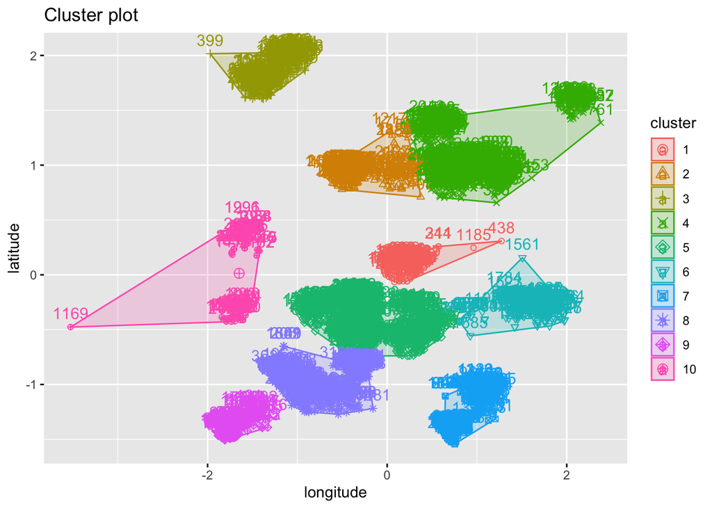

```r
#visualise clsuters
fviz_cluster(employees_clusters,
             choose.vars = c("longitude",
                             "latitude"),
             data = employees_g)
```

```r
             # geom = "points")
```

```r
#Assign each address to the corresponding cluster
employees_g$clusters = employees_clusters$cluster
#Store 10 Cluster centroids
cluster_centroids <- data.frame(longitude = employees_clusters$centers[, 1],
                                latitude  = employees_clusters$centers[, 2]
                               )

#Find, for each centroid, the closest bus stop. We use geographical distance here for simplicity and to not have to call APIs. We could very well use walking distance by calling some map API, similarly to how we found out lat/lon from the address

all_distances = distm(cluster_centroids, stops_g, fun = distHaversine)
#each row is one of the 10 clusters and each column is one of the 119 stops. The corresponding value is the distance
dim(all_distances)
```

```
## [1]  10 119
```

```r
#Find the closest bus stop for each cluster
index_best_stops = apply(all_distances, 1, which.min)
#Best stops
stops[index_best_stops,]
```

```
## # A tibble: 10 × 2
##    Street_One Street_Two
##    <chr>      <chr>
##  1 MISSION ST 29TH ST
##  2 MISSION ST ERIE ST
##  3 MISSION ST 01ST ST
##  4 MISSION ST 10TH ST
##  5 MISSION ST TRUMBULL ST
##  6 MISSION ST 30TH ST
##  7 MISSION ST RUSSIA AVE
##  8 MISSION ST ITALY AVE
##  9 MISSION ST LAWRENCE AVE
## 10 MISSION ST APPLETON AVE
```

[figure not shown]

```r
#Let's plot final best stops and employee addresses/clusters
ssbox <- make_bbox(lon = c(min(employees_g$longitude), max(employees_g$longitude)),
                   lat = c(min(employees_g$latitude), max(employees_g$latitude)))
sq_map <- get_map(location = ssbox, maptype = "roadmap")


ggmap(sq_map) +
  geom_point(data = employees_g, mapping = aes(x = longitude, y = latitude, color = as.factor(clusters))) +
  geom_point(data = stops_g[index_best_stops,], mapping = aes(x = longitude, y = latitude), size = 3.5, shape = 17, color = "red") +
  coord_quickmap()
```

## 3.2 Next Steps

There are at least a couple of ways the outcome could be improved from a product standpoint:

1. When we optimize the bus stops, we are considering all the employees. However this might not make sense. If someone is really far from their closest bus stop, they might not take the shuttle anyway. And, even if they are going to take it, it won’t make much of a difference a 25 vs a 30 minute distance. There is probably not much point in optimizing for these people. Therefore, they could be removed before doing the clustering or we could reduce their weight right before clustering.
2. If two optimal bus stops end up being very close, this would be inefficient from a practical standpoint. Assume 2 bus stops are within 2 minutes from each other. It would definitely be more efficient merging those two into one stop and either just having 9 stops or adding a new one. From an algorithm standpoint, this would translate into adding a constraint when the cluster centroids are created such that their distance cannot be <X.